# Procesamiento de datos de accidentes de tráfico en Madrid

# 1. Cargamos las librerías, datos y configuraciones previas

Al estar trabajando en con Jupyter Notebooks en ArcGIS Online realizamos una previa configuración del directorio de trabajo.

```python
from arcgis.gis import GIS # librería de Arcgis para iniciar el trabajo en Arcgis Online
gis = GIS("home")
import pandas as pd
import os
import arcpy
```

Comprobamos el directorio de trabajo.

```python
path = os.getcwd()
print ("El directrio de trabajo es:  %s" % path)
```

```
El directrio de trabajo es:  /arcgis
```

Creamos un nuevo directorio para almacenar los datos que nos descargamos del Open Data de Madrid, en el código escribimos el nombre del directorio y si existe el directorio no lo vuelve a crear para no duplicarlo o borrarlo.

```python
path = "/arcgis/datos_originales"

try:
    os.mkdir(path)
except OSError:
    print ("El directorio de trabajo %s ya exisite" % path)
else:
    print ("El Directrorio de trabajo %s creado con éxito" % path)
```

```
El directorio de trabajo /arcgis/datos_originales ya exisite
```

Nos descargamos del [portal de datos abiertos del Madrid](https://datos.madrid.es/) los accidentes de tráfico en la ciudad de Madrid registrados por la Policía Municipal. Los datos que figuran son desde el 2010 hasta el 2020, concretamente se encuentran en este [link](https://datos.madrid.es/sites/v/index.jsp?vgnextoid=7c2843010d9c3610VgnVCM2000001f4a900aRCRD&vgnextchannel=374512b9ace9f310VgnVCM100000171f5a0aRCRD).

Los datos recogidos del 2010 hasta el 2018 no tienen los mismos campos que los del 2019 y 2020. En el año **2019 y posteriores,** no se recoge la información meteorológica tan detallada, por es solo conservaremos una variable resumen de las condiciones meteorológicas y tampoco se incluyen el número de víctimas.

## Lectura de datos del directorio de ArcGIS Online

Leemos todos los ficheros excel desde el área de contenidos de nuestra organización.

```python
df_2010 = pd.read_excel('/arcgis/datos_originales/2010_Accidentalidad.xlsx')
df_2011 = pd.read_excel('/arcgis/datos_originales/2011_Accidentalidad.xlsx')
df_2012 = pd.read_excel('/arcgis/datos_originales/2012_Accidentalidad.xlsx')
df_2013 = pd.read_excel('/arcgis/datos_originales/2013_Accidentalidad.xlsx')
df_2014 = pd.read_excel('/arcgis/datos_originales/2014_Accidentalidad.xlsx')
df_2015 = pd.read_excel('/arcgis/datos_originales/2015_Accidentalidad.xlsx')
df_2016 = pd.read_excel('/arcgis/datos_originales/2016_Accidentalidad.xlsx')
df_2017 = pd.read_excel('/arcgis/datos_originales/2017_Accidentalidad.xlsx')
df_2018 = pd.read_excel('/arcgis/datos_originales/2018_Accidentalidad.xlsx')
df_2019 = pd.read_excel('/arcgis/datos_originales/2019_Accidentalidad.xlsx')
df_2020 = pd.read_excel('/arcgis/datos_originales/2020_Accidentalidad.xlsx')
```

# 2. Limpiamos los datos

Para poder analizar los datos queremos unir todos los conjuntos de datos en uno solo, para ello antes realizamos una serie de comprobaciones:

- Dimensiones de todo los conjuntos de datos.
- Todos los conjuntos de datos han de tener el mismo encabezado.
- Y todas las variables han de tener el mismo formato.

```python
print (' Dimensiones de dataframe 2010',df_2010.shape, '\n',
       'Dimensiones de dataframe 2011',df_2011.shape, '\n',
       'Dimensiones de dataframe 2012',df_2012.shape, '\n',
       'Dimensiones de dataframe 2013',df_2013.shape, '\n',
       'Dimensiones de dataframe 2014',df_2014.shape, '\n',
       'Dimensiones de dataframe 2015',df_2015.shape, '\n',
       'Dimensiones de dataframe 2016',df_2016.shape, '\n',
       'Dimensiones de dataframe 2017',df_2017.shape, '\n',
       'Dimensiones de dataframe 2018',df_2018.shape, '\n',
       'Dimensiones de dataframe 2019',df_2019.shape, '\n',
       'Dimensiones de dataframe 2020',df_2020.shape, '\n',
      )
```

```
 Dimensiones de dataframe 2010 (26578, 26)
 Dimensiones de dataframe 2011 (27342, 26)
 Dimensiones de dataframe 2012 (26982, 26)
 Dimensiones de dataframe 2013 (26839, 26)
 Dimensiones de dataframe 2014 (27967, 26)
 Dimensiones de dataframe 2015 (28172, 26)
 Dimensiones de dataframe 2016 (29201, 26)
 Dimensiones de dataframe 2017 (29795, 26)
 Dimensiones de dataframe 2018 (30122, 26)
 Dimensiones de dataframe 2019 (51806, 14)
 Dimensiones de dataframe 2020 (32420, 15)
```

Vemos que los datasets tienen distintos números de variables así que nos quedamos con aquellos más representativos para nuestro análisis.

Comprobamos el encabezado y las primeras observaciones de cada conjunto de datos, para comprobar lo comentado anteriormente descrito y empezar con la edición de los datos.

```python
df_2019.head(3)
```

|  | Nº EXPEDIENTE | FECHA | HORA | CALLE | NÚMERO | DISTRITO | TIPO ACCIDENTE | ESTADO METEREOLÓGICO | TIPO VEHÍCULO | TIPO PERSONA | RANGO EDAD | SEXO | LESIVIDAD* | * La correspondencia de los códigos se encuentra descrito en la estructura del fichero. |
| --- | --- | --- | --- | --- | --- | --- | --- | --- | --- | --- | --- | --- | --- | --- |
| 0 | 2019S000020 | 01/01/2019 | 23:30:00 | CALL. FUENCARRAL | 149 | CHAMBERÍ | Caída | Despejado | Ciclomotor | Conductor | DE 25 A 29 AÑOS | Hombre | 1.0 | NaN |
| 1 | 2019S000017 | 01/01/2019 | 22:15:00 | CALL. OCA / CALL. PINZON | - | CARABANCHEL | Colisión fronto-lateral | Despejado | Turismo | Conductor | DE 40 A 44 AÑOS | Mujer | 14.0 | NaN |
| 2 | 2019S000017 | 01/01/2019 | 22:15:00 | CALL. OCA / CALL. PINZON | - | CARABANCHEL | Colisión fronto-lateral | Despejado | Ciclomotor | Conductor | DE 35 A 39 AÑOS | Hombre | 3.0 | NaN |

```python
del df_2019['* La correspondencia de los códigos se encuentra descrito en la estructura del fichero.']
```

```python
df_2020.head(3)
```

|  | Nº EXPEDIENTE | FECHA | HORA | CALLE | NÚMERO | DISTRITO | TIPO ACCIDENTE | ESTADO METEREOLÓGICO | TIPO VEHÍCULO | TIPO PERSONA | RANGO DE EDAD | SEXO | LESIVIDAD* | Unnamed: 13 | Unnamed: 14 |
| --- | --- | --- | --- | --- | --- | --- | --- | --- | --- | --- | --- | --- | --- | --- | --- |
| 0 | 2020S000057 | 01/01/2020 | 23:15:00 | AVDA. CIUDAD DE BARCELONA / CALL. DOCTOR ESQUERDO | - | RETIRO | Choque contra obstáculo fijo | Despejado | Turismo | Conductor | DE 25 A 29 AÑOS | Hombre | NaN | NaN | NaN |
| 1 | 2020S000038 | 01/01/2020 | 22:35:00 | CALL. VALLE DE TORANZO / CALL. SIERRA DE PAJAREJO | - | MONCLOA-ARAVACA | Caída | Despejado | Ciclomotor | Conductor | DE 21 A 24 AÑOS | Mujer | 6.0 | NaN | NaN |
| 2 | 2020S000060 | 01/01/2020 | 20:15:00 | GTA. MARIANO SALVADOR MAELLA | 1 | FUENCARRAL-EL PARDO | Caída | Despejado | Turismo | Conductor | DE 45 A 49 AÑOS | Hombre | 14.0 | NaN | NaN |

Eliminamos las variables que no nos sirven.

```python
del df_2020['Unnamed: 13']
del df_2020['Unnamed: 14']
```

Comparamos el nombre de las columnas del 2010 hasta el 2018 para ver si coinciden ya que tienen 26 variables.

```python
print('Comparamos encabezado 2010 con 2011:' ,"\n", df_2010.columns == df_2011.columns, "\n", "\n",
      'Comparamos encabezado 2010 con 2012:' ,"\n", df_2010.columns == df_2012.columns, "\n", "\n",
      'Comparamos encabezado 2010 con 2013:' ,"\n", df_2010.columns == df_2013.columns, "\n", "\n",
      'Comparamos encabezado 2010 con 2014:' ,"\n", df_2010.columns == df_2014.columns, "\n", "\n",
      'Comparamos encabezado 2010 con 2015:' ,"\n", df_2010.columns == df_2015.columns, "\n", "\n",
      'Comparamos encabezado 2010 con 2016:' ,"\n", df_2010.columns == df_2016.columns, "\n", "\n",
      'Comparamos encabezado 2010 con 2017:' ,"\n", df_2010.columns == df_2017.columns, "\n", "\n",
      'Comparamos encabezado 2010 con 2018:' ,"\n", df_2010.columns == df_2018.columns, "\n", "\n"
     )
```

```
Comparamos encabezado 2010 con 2011:
 [ True  True  True  True  True  True  True  True  True  True  True  True  True  True  True  True  True  True  True
  True  True  True  True  True  True  True]

 Comparamos encabezado 2010 con 2012:
 [ True  True  True  True  True  True  True  True  True  True  True  True  True  True  True  True  True  True  True
  True  True  True  True  True  True  True]

 Comparamos encabezado 2010 con 2013:
 [ True  True  True  True  True  True  True  True  True  True  True  True  True  True  True  True  True  True  True
  True  True  True  True  True  True  True]

 Comparamos encabezado 2010 con 2014:
 [ True  True  True  True  True  True  True  True  True  True  True  True  True  True  True  True  True  True  True
  True  True  True  True  True  True  True]

 Comparamos encabezado 2010 con 2015:
 [ True  True  True  True  True  True  True  True  True  True  True  True  True  True  True  True  True  True  True
  True  True  True  True  True  True  True]

 Comparamos encabezado 2010 con 2016:
 [ True  True  True  True  True  True  True  True  True  True  True  True  True  True  True  True  True  True  True
 False  True  True  True  True  True  True]

 Comparamos encabezado 2010 con 2017:
 [ True  True  True  True  True  True  True  True  True  True  True  True  True  True  True  True  True  True  True
  True  True  True  True  True  True  True]

 Comparamos encabezado 2010 con 2018:
 [ True  True  True  True  True  True  True  True  True  True  True  True  True  True  True  True  True  True  True
 False  True  True  True  True  True  True]
```

```python
encabezado = df_2010.columns
df_2018.columns = encabezado
```

Hacemos el mismo proceso con el dataset 2019 y 2020 y volvemos a comprobarlo.

```python
print('Comparamos encabezado 2019 con 2020:' ,"\n", df_2019.columns == df_2020.columns)
```

```
Comparamos encabezado 2019 con 2020:
 [ True  True  True  True  True  True  True  True  True  True False  True  True]
```

Vemos que de nuevo no coinciden los nombres de las columnas, así que los renombraremos.

```python
encabezado2 = df_2019.columns
df_2020.columns = encabezado2
```

Unimos los dataset del 2010 al 2018

```python
lista_dataframes = [df_2010, df_2011, df_2012, df_2013, df_2014, df_2015, df_2016, df_2017, df_2018]
df_2010_2018 = pd.concat(lista_dataframes)
```

Unimos los dataset del 2019 al 2020

```python
lista_dataframes = [df_2019, df_2020]
df_2019_2020 = pd.concat(lista_dataframes)
```

Ahora unimos todas las columnas meteorológicas en una sola columna.

```python
df_2010_2018.columns
```

```
Index(['FECHA', 'RANGO HORARIO', 'DIA SEMANA', 'DISTRITO', 'LUGAR ACCIDENTE',
       'Nº', 'Nº PARTE', 'CPFA Granizo', 'CPFA Hielo', 'CPFA Lluvia',
       'CPFA Niebla', 'CPFA Seco', 'CPFA Nieve', 'CPSV Mojada', 'CPSV Aceite',
       'CPSV Barro', 'CPSV Grava Suelta', 'CPSV Hielo', 'CPSV Seca Y Limpia',
       'Nº VICTIMAS *', 'TIPO ACCIDENTE', 'Tipo Vehiculo', 'TIPO PERSONA',
       'SEXO', 'LESIVIDAD', 'Tramo Edad', 'Nº VICTIMAS * '],
      dtype='object')
```

```python
df_2010_2018.columns = [c.replace(' ', '_') for c in df_2010_2018.columns]
```

```python
import numpy as np
df_2010_2018['CPFA_Granizo'] = np.where(df_2010_2018['CPFA_Granizo']=='SI', 'granizo', 0)
df_2010_2018['CPFA_Hielo'] = np.where(df_2010_2018['CPFA_Hielo']=='SI', 'hielo', 0)
df_2010_2018['CPFA_Lluvia'] = np.where(df_2010_2018['CPFA_Lluvia']=='SI', 'lluvia', 0)
df_2010_2018['CPFA_Niebla'] = np.where(df_2010_2018['CPFA_Niebla']=='SI', 'niebla', 0)
df_2010_2018['CPFA_Seco'] = np.where(df_2010_2018['CPFA_Seco']=='SI', 'seco', 0)
df_2010_2018['CPFA_Nieve'] = np.where(df_2010_2018['CPFA_Nieve']=='SI', 'nieve', 0)
```

```python
df_2010_2018["ESTADO_METEREOLÓGICO"] = df_2010_2018["CPFA_Granizo"] + '-' + df_2010_2018["CPFA_Hielo"]+ '-' + df_2010_2018["CPFA_Lluvia"]+ '-' + df_2010_2018["CPFA_Niebla"]+ '-' +df_2010_2018["CPFA_Seco"]+ '-'+ df_2010_2018["CPFA_Nieve"]
```

```python
df_2010_2018.ESTADO_METEREOLÓGICO = [c.replace('0-', '') for c in df_2010_2018.ESTADO_METEREOLÓGICO]
df_2010_2018.ESTADO_METEREOLÓGICO = [c.replace('-0', '') for c in df_2010_2018.ESTADO_METEREOLÓGICO]
```

Renombramos la columnas.

```python
df_2010_2018 = df_2010_2018.rename(columns={"Nº_PARTE": "Nº_EXPEDIENTE", "RANGO_HORARIO" :"HORA", "LUGAR_ACCIDENTE":"CALLE",
                                            "Nº":"NÚMERO", "Tipo_Vehiculo":"TIPO_VEHÍCULO","Tramo_Edad":"RANGO_DE_EDAD", "LESIVIDAD": "LESIVIDAD*"})
```

Seleccionamos para los datasets del 2010 al 2018 las columnas que aparecen en 2019 y 2020.

```python
df_2010_2018 = df_2010_2018.loc[:,['Nº_EXPEDIENTE', 'FECHA', 'HORA', 'CALLE', 'NÚMERO', 'DISTRITO',
                                   'TIPO_ACCIDENTE','ESTADO_METEREOLÓGICO', 'TIPO_VEHÍCULO',
                                   'TIPO_PERSONA', 'RANGO_DE_EDAD','SEXO', 'LESIVIDAD*']]
```

Modificamos y unificamos el formato de la variable hora.

```python
df_2010_2018.HORA = [c.replace("DE 00:00 A 00:59", "00:30:00") for c in df_2010_2018.HORA]
df_2010_2018.HORA = [c.replace("DE 1:00 A 1:59", "01:30:00") for c in df_2010_2018.HORA]
df_2010_2018.HORA = [c.replace("DE 2:00 A 2:59", "02:30:00") for c in df_2010_2018.HORA]
df_2010_2018.HORA = [c.replace("DE 3:00 A 3:59", "03:30:00") for c in df_2010_2018.HORA]
df_2010_2018.HORA = [c.replace("DE 4:00 A 4:59", "04:30:00") for c in df_2010_2018.HORA]
df_2010_2018.HORA = [c.replace("DE 5:00 A 5:59", "05:30:00") for c in df_2010_2018.HORA]
df_2010_2018.HORA = [c.replace("DE 6:00 A 6:59", "06:30:00") for c in df_2010_2018.HORA]
df_2010_2018.HORA = [c.replace("DE 7:00 A 7:59", "07:30:00") for c in df_2010_2018.HORA]
df_2010_2018.HORA = [c.replace("DE 8:00 A 8:59", "08:30:00") for c in df_2010_2018.HORA]
df_2010_2018.HORA = [c.replace("DE 9:00 A 9:59", "09:30:00") for c in df_2010_2018.HORA]
df_2010_2018.HORA = [c.replace("DE 10:00 A 10:59", "10:30:00") for c in df_2010_2018.HORA]
df_2010_2018.HORA = [c.replace("DE 11:00 A 11:59", "11:30:00") for c in df_2010_2018.HORA]
df_2010_2018.HORA = [c.replace("DE 12:00 A 12:59", "12:30:00") for c in df_2010_2018.HORA]
df_2010_2018.HORA = [c.replace("DE 13:00 A 13:59", "13:30:00") for c in df_2010_2018.HORA]
df_2010_2018.HORA = [c.replace("DE 14:00 A 14:59", "14:30:00") for c in df_2010_2018.HORA]
df_2010_2018.HORA = [c.replace("DE 15:00 A 15:59", "15:30:00") for c in df_2010_2018.HORA]
df_2010_2018.HORA = [c.replace("DE 16:00 A 16:59", "16:30:00") for c in df_2010_2018.HORA]
df_2010_2018.HORA = [c.replace("DE 17:00 A 17:59", "17:30:00") for c in df_2010_2018.HORA]
df_2010_2018.HORA = [c.replace("DE 18:00 A 18:59", "18:30:00") for c in df_2010_2018.HORA]
df_2010_2018.HORA = [c.replace("DE 19:00 A 19:59", "19:30:00") for c in df_2010_2018.HORA]
df_2010_2018.HORA = [c.replace("DE 20:00 A 20:59", "20:30:00") for c in df_2010_2018.HORA]
df_2010_2018.HORA = [c.replace("DE 21:00 A 21:59", "21:30:00") for c in df_2010_2018.HORA]
df_2010_2018.HORA = [c.replace("DE 22:00 A 22:59", "22:30:00") for c in df_2010_2018.HORA]
df_2010_2018.HORA = [c.replace("DE 23:00 A 23:59", "23:30:00") for c in df_2010_2018.HORA]
```

Visualizamos el resultado.

```python
print(df_2010_2018.columns)
```

```
Index(['Nº_EXPEDIENTE', 'FECHA', 'HORA', 'CALLE', 'NÚMERO', 'DISTRITO',
       'TIPO_ACCIDENTE', 'ESTADO_METEREOLÓGICO', 'TIPO_VEHÍCULO',
       'TIPO_PERSONA', 'RANGO_DE_EDAD', 'SEXO', 'LESIVIDAD*'],
      dtype='object')
```

```python
df_2010_2018.info()
```

```
<class 'pandas.core.frame.DataFrame'>
Int64Index: 252998 entries, 0 to 30121
Data columns (total 13 columns):
 #   Column                Non-Null Count   Dtype
---  ------                --------------   -----
 0   Nº_EXPEDIENTE         252998 non-null  object
 1   FECHA                 252998 non-null  datetime64[ns]
 2   HORA                  252998 non-null  object
 3   CALLE                 252998 non-null  object
 4   NÚMERO                252998 non-null  object
 5   DISTRITO              252998 non-null  object
 6   TIPO_ACCIDENTE        252998 non-null  object
 7   ESTADO_METEREOLÓGICO  252998 non-null  object
 8   TIPO_VEHÍCULO         252998 non-null  object
 9   TIPO_PERSONA          252998 non-null  object
 10  RANGO_DE_EDAD         252998 non-null  object
 11  SEXO                  252998 non-null  object
 12  LESIVIDAD*            252998 non-null  object
dtypes: datetime64[ns](1), object(12)
memory usage: 27.0+ MB
```

```python
# convertimos la fecha en formato fecha del dataset df_2010_2018
df_2010_2018['FECHA']= pd.to_datetime(df_2010_2018['FECHA'])
```

```python
# convertimos la fecha en formato fecha del dataset df_2019_2020
df_2019_2020['FECHA']= pd.to_datetime(df_2019_2020['FECHA'])
```

```python
df_2010_2018.info()
```

```
<class 'pandas.core.frame.DataFrame'>
Int64Index: 252998 entries, 0 to 30121
Data columns (total 13 columns):
 #   Column                Non-Null Count   Dtype
---  ------                --------------   -----
 0   Nº_EXPEDIENTE         252998 non-null  object
 1   FECHA                 252998 non-null  datetime64[ns]
 2   HORA                  252998 non-null  object
 3   CALLE                 252998 non-null  object
 4   NÚMERO                252998 non-null  object
 5   DISTRITO              252998 non-null  object
 6   TIPO_ACCIDENTE        252998 non-null  object
 7   ESTADO_METEREOLÓGICO  252998 non-null  object
 8   TIPO_VEHÍCULO         252998 non-null  object
 9   TIPO_PERSONA          252998 non-null  object
 10  RANGO_DE_EDAD         252998 non-null  object
 11  SEXO                  252998 non-null  object
 12  LESIVIDAD*            252998 non-null  object
dtypes: datetime64[ns](1), object(12)
memory usage: 27.0+ MB
```

```python
df_2019_2020.info()
```

```
<class 'pandas.core.frame.DataFrame'>
Int64Index: 84226 entries, 0 to 32419
Data columns (total 13 columns):
 #   Column                Non-Null Count  Dtype
---  ------                --------------  -----
 0   Nº  EXPEDIENTE        84226 non-null  object
 1   FECHA                 84226 non-null  datetime64[ns]
 2   HORA                  84226 non-null  object
 3   CALLE                 84226 non-null  object
 4   NÚMERO                84220 non-null  object
 5   DISTRITO              84219 non-null  object
 6   TIPO ACCIDENTE        84188 non-null  object
 7   ESTADO METEREOLÓGICO  75869 non-null  object
 8   TIPO VEHÍCULO         83882 non-null  object
 9   TIPO PERSONA          84172 non-null  object
 10  RANGO EDAD            84226 non-null  object
 11  SEXO                  75359 non-null  object
 12  LESIVIDAD*            47644 non-null  float64
dtypes: datetime64[ns](1), float64(1), object(11)
memory usage: 9.0+ MB
```

Y por último unificamos todos los datasetes, y nuestro nuevo conjunto de datos lo llamamos **df_2010_2020**.

```python
lista_dataframes = [df_2010_2018, df_2019_2020]
df_2010_2020 = pd.concat(lista_dataframes)
```

```python
df_2010_2020.info()
```

```
<class 'pandas.core.frame.DataFrame'>
Int64Index: 337224 entries, 0 to 32419
Data columns (total 19 columns):
 #   Column                Non-Null Count   Dtype
---  ------                --------------   -----
 0   Nº_EXPEDIENTE         252998 non-null  object
 1   FECHA                 337224 non-null  datetime64[ns]
 2   HORA                  337224 non-null  object
 3   CALLE                 337224 non-null  object
 4   NÚMERO                337218 non-null  object
 5   DISTRITO              337217 non-null  object
 6   TIPO_ACCIDENTE        252998 non-null  object
 7   ESTADO_METEREOLÓGICO  252998 non-null  object
 8   TIPO_VEHÍCULO         252998 non-null  object
 9   TIPO_PERSONA          252998 non-null  object
 10  RANGO_DE_EDAD         252998 non-null  object
 11  SEXO                  328357 non-null  object
 12  LESIVIDAD*            300642 non-null  object
 13  Nº  EXPEDIENTE        84226 non-null   object
 14  TIPO ACCIDENTE        84188 non-null   object
 15  ESTADO METEREOLÓGICO  75869 non-null   object
 16  TIPO VEHÍCULO         83882 non-null   object
 17  TIPO PERSONA          84172 non-null   object
 18  RANGO EDAD            84226 non-null   object
dtypes: datetime64[ns](1), object(18)
memory usage: 51.5+ MB
```

# 3. Visualización y dinámica temporal

```python
import matplotlib.pyplot as plot
```

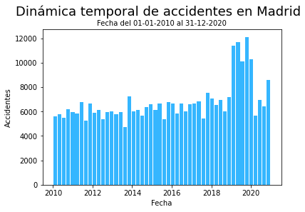

```python
# Creamos el gráfifico tipo histograma
plot.hist(df_2010_2020['FECHA'], bins=50, color='#35b6ff', rwidth=0.85)
plot.suptitle('Dinámica temporal de accidentes en Madrid', y=1, fontsize=18)
plot.title('Fecha del 01-01-2010 al 31-12-2020', fontsize=10)
plot.xlabel('Fecha')
plot.ylabel('Accidentes')

plot.show()
```

```python
df_2010_2020['FECHA'].groupby(df_2010_2020.FECHA.dt.year).agg('count')
```

```
FECHA
2010    26578
2011    27342
2012    26982
2013    26839
2014    27967
2015    28172
2016    29201
2017    29795
2018    30122
2019    51806
2020    32420
Name: FECHA, dtype: int64
```

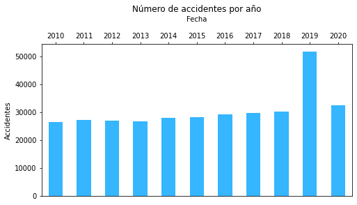

```python
ax = df_2010_2020['FECHA'].groupby(df_2010_2020.FECHA.dt.year).agg('count').plot(
       kind = 'bar',
       color='#35b6ff',
       figsize = (8,4),
       title = "Número de accidentes por año")

ax.set_xlabel("Fecha\n", y=2)
ax.set_ylabel("Accidentes")
ax.xaxis.set_label_position('top')
ax.xaxis.set_ticks_position('top')
```

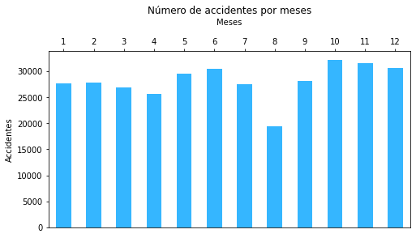

```python
ax = df_2010_2020['FECHA'].groupby(df_2010_2020.FECHA.dt.month).agg('count').plot(
       kind = 'bar',
       color='#35b6ff',
       figsize = (8,4),
       title = "Número de accidentes por meses")

ax.set_xlabel("Meses\n", y=2)
ax.set_ylabel("Accidentes")
ax.xaxis.set_label_position('top')
ax.xaxis.set_ticks_position('top')
```

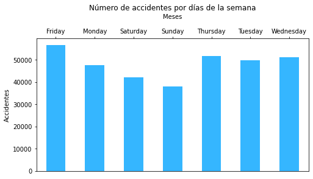

```python
ax = df_2010_2020['FECHA'].groupby(df_2010_2020.FECHA.dt.day_name()).agg('count').plot(
       kind = 'bar',
       color='#35b6ff',
       figsize = (8,4),
       title = "Número de accidentes por días de la semana")

ax.set_xlabel("Meses\n", y=2)
ax.set_ylabel("Accidentes")
ax.xaxis.set_label_position('top')
ax.xaxis.set_ticks_position('top')
```

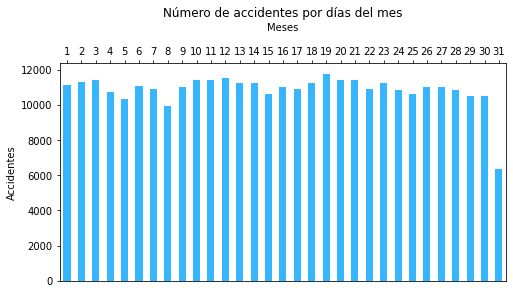

```python
ax = df_2010_2020['FECHA'].groupby(df_2010_2020.FECHA.dt.day).agg('count').plot(
       kind = 'bar',
       color='#35b6ff',
       figsize = (8,4),
       title = "Número de accidentes por días del mes")

ax.set_xlabel("Meses\n", y=2)
ax.set_ylabel("Accidentes")
ax.xaxis.set_label_position('top')
ax.xaxis.set_ticks_position('top')
```

```python
df_2010_2020['SEXO'].value_counts()
```

```
HOMBRE         160165
MUJER           80717
Hombre          51082
Mujer           24277
NO ASIGNADO     12116
Name: SEXO, dtype: int64
```

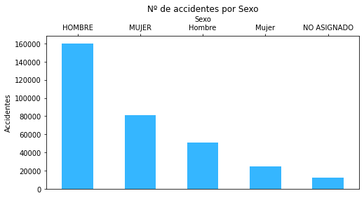

```python
ax = df_2010_2020['SEXO'].value_counts().plot(
    kind='bar',
    color='#35b6ff',
    figsize=(8,4),
    title="Nº de accidentes por Sexo")
ax.set_xlabel("Sexo")
ax.set_ylabel("Accidentes")
ax.xaxis.set_label_position('top')
ax.xaxis.set_ticks_position('top')
```